# Visualización: gráficos con ggplot2

### 7.3 Labelling las observaciones con ggrepel

El gráfico de abajo se basa en [este post](https://juliasilge.com/blog/lubridate-london-stage/) de Julia Silge. Utiliza el paquete [`ggrepel](https://github.com/slowkow/ggrepel) para poder ver a quien pertenece la observación en un gráfico de puntos.

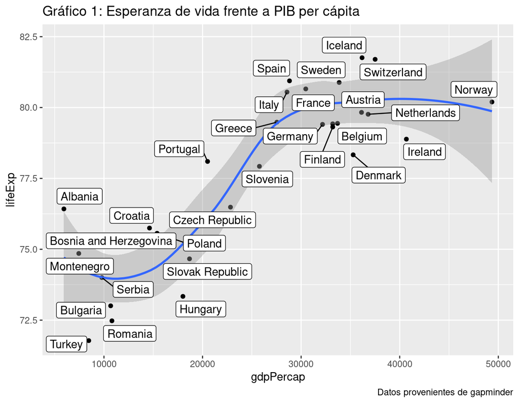

```r
library(ggrepel)
df <- gapminder::gapminder %>% filter(year == "2007")  %>% filter(continent == "Europe")
ggplot(df, aes(gdpPercap, lifeExp, label = country)) + geom_point() +
     labs(title = "Gráfico 1: Esperanza de vida frente a PIB per cápita" ,
       caption = "Datos provenientes de gapminder",
       y = "lifeExp",
       x = "gdpPercap") + geom_smooth() +
        geom_label_repel()
```

### 7.4 `GGally` package

Hay muchos paquetes que proporcionan formas rápidas de hacer gráficos como por ejemplo este del paquete [`GGally`](https://ggobi.github.io/ggally/index.html):

[figure not shown]

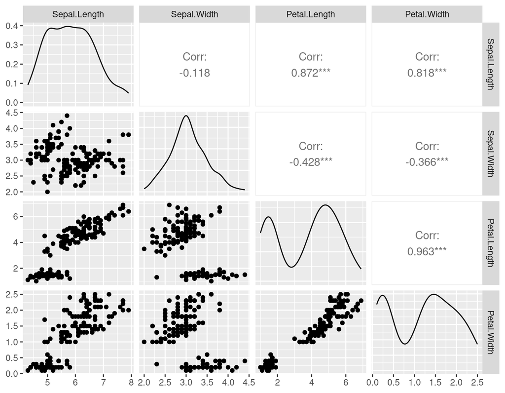

```r
library(GGally)
ggpairs(iris)
ggpairs(iris %>% select(1:4) %>% na.omit(), progress = FALSE, lower = list(combo = wrap("facethist", bins=6)))
```

### 7.5 Un poco más de anotaciones

Para que un gráfico sea efectivo y nos haga ver algún hecho o característica de los datos, muchas veces es preciso hacer anotaciones en el gráfico para señalar o resaltar ciertos aspectos de este. En esta subsección presento algún ejemplo de uso de las anotaciones en gráficos ggplot.

- En primer lugar un ejemplo de Hadley. Hadley nos dice que no hay nada novedoso excepto el uso de -Inf and Inf como posiciones para referirse a los límites del gráfico, the top and bottom (or left and right) limits of the plot.

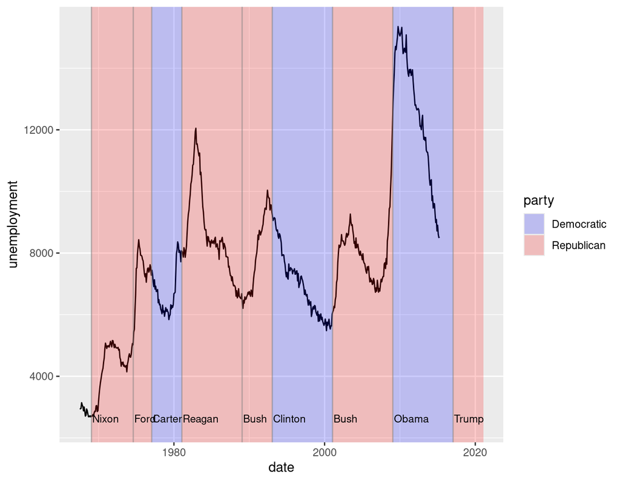

```r
presidential <- subset(presidential, start > economics$date[1])

p <- ggplot(economics) +  geom_line(aes(date, unemploy)) +
  scale_fill_manual(values = c("blue", "red")) +
  xlab("date") +
  ylab("unemployment")

#- comienzan las anotaciones
p + geom_rect(aes(xmin = start, xmax = end, fill = party),
              ymin = -Inf, ymax = Inf, alpha = 0.2, data = presidential) +
    geom_vline(aes(xintercept = as.numeric(start)),
               data = presidential, colour = "grey50", alpha = 0.5) +
    geom_text(aes(x = start, y = 2500, label = name),
               data = presidential, size = 3, vjust = 0, hjust = 0, nudge_x = 50)
```

Una forma común de anotación consiste en marcar o subrayar un conjunto de puntos. Por ejemplo marcar los coches de la marca Subaru en el siguiente gráfico. Se puede hacer de la siguiente manera:

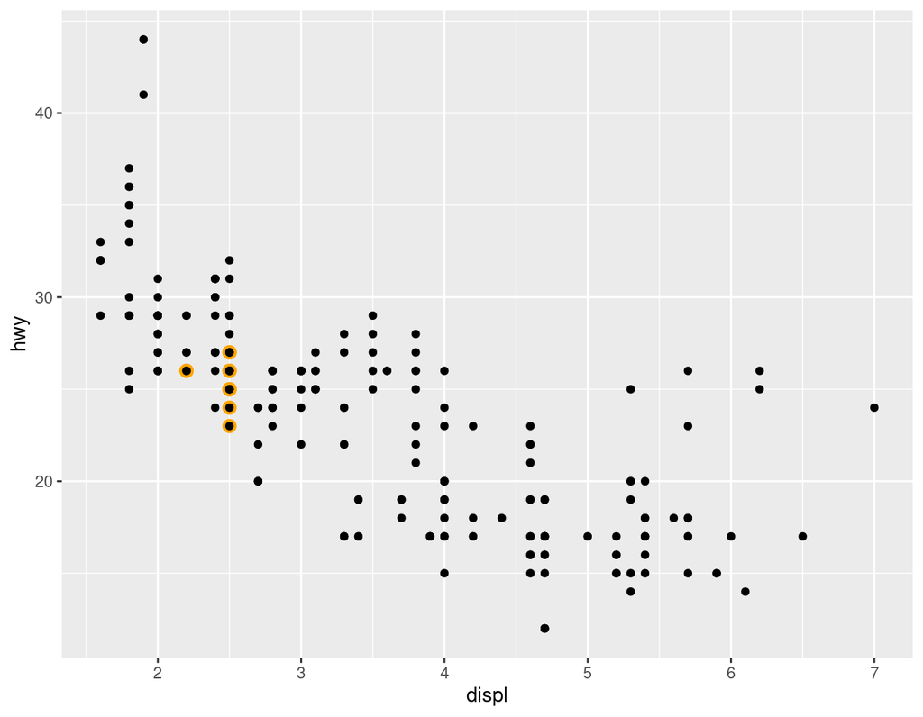

```r
p <- ggplot(mpg, aes(displ, hwy)) +
  geom_point(data = filter(mpg, manufacturer == "subaru"), colour = "orange", size = 3) +
  geom_point()
p
```

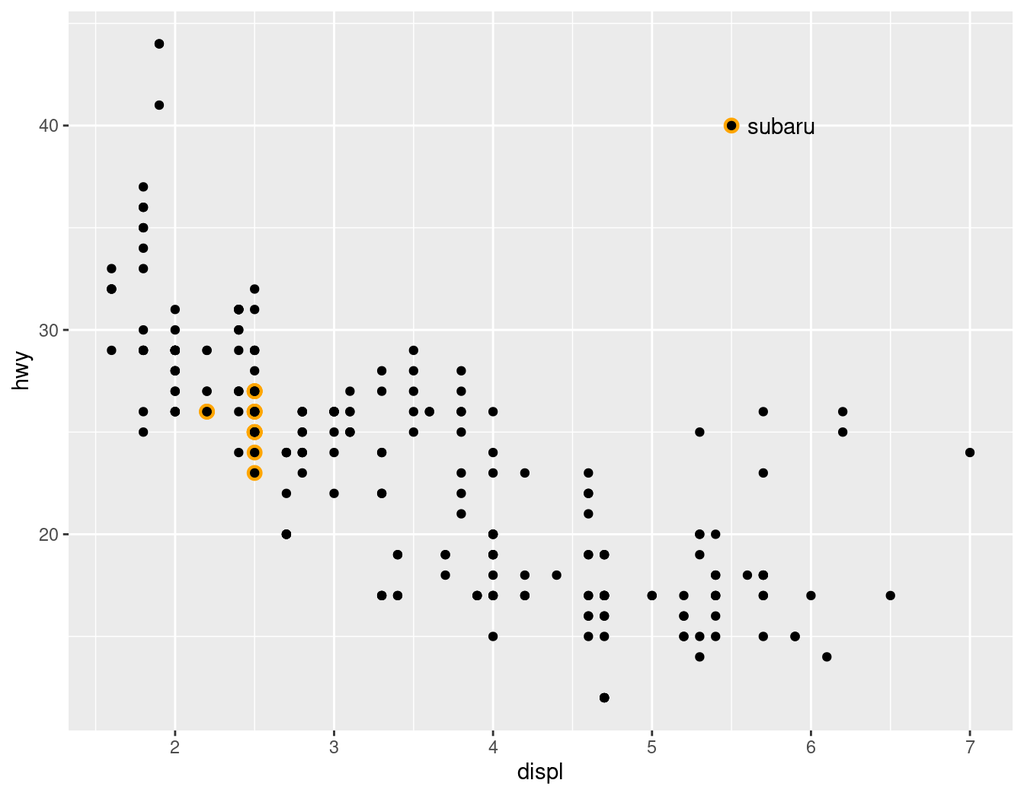

```r
p + annotate(geom = "point", x = 5.5, y = 40, colour = "orange", size = 3) +
    annotate(geom = "point", x = 5.5, y = 40) +
    annotate(geom = "text", x = 5.6, y = 40, label = "subaru", hjust = "left")
```

O de esta otra forma:

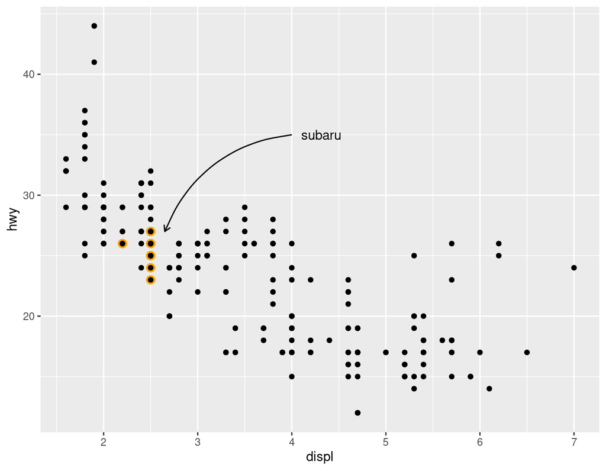

```r
p + annotate(geom = "curve", x = 4, y = 35, xend = 2.65, yend = 27,
              curvature = .3, arrow = arrow(length = unit(2, "mm"))) +
   annotate(geom = "text", x = 4.1, y = 35, label = "subaru", hjust = "left")
```

El paquete [`ggforce`](https://ggforce.data-imaginist.com/) es una extensión a ggplot2 que puede servir para muchas cosas, entre ellas hacer anotaciones o marcas en gráficos ggplot. Por ejemplo:

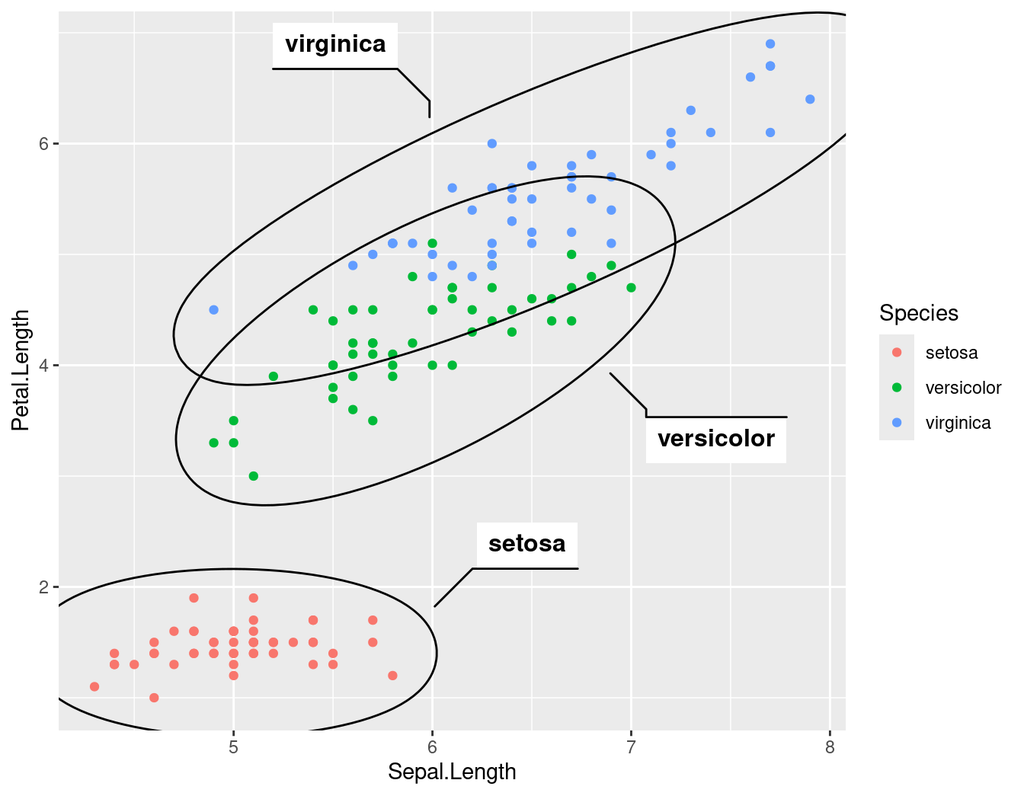

```r
ggplot(iris, aes(Sepal.Length, Petal.Length)) +
  geom_point(aes(color = Species)) +
  ggforce::geom_mark_ellipse(aes(label = Species, group = Species))
```

Con `ggforce` podemos hasta simular un zoom:

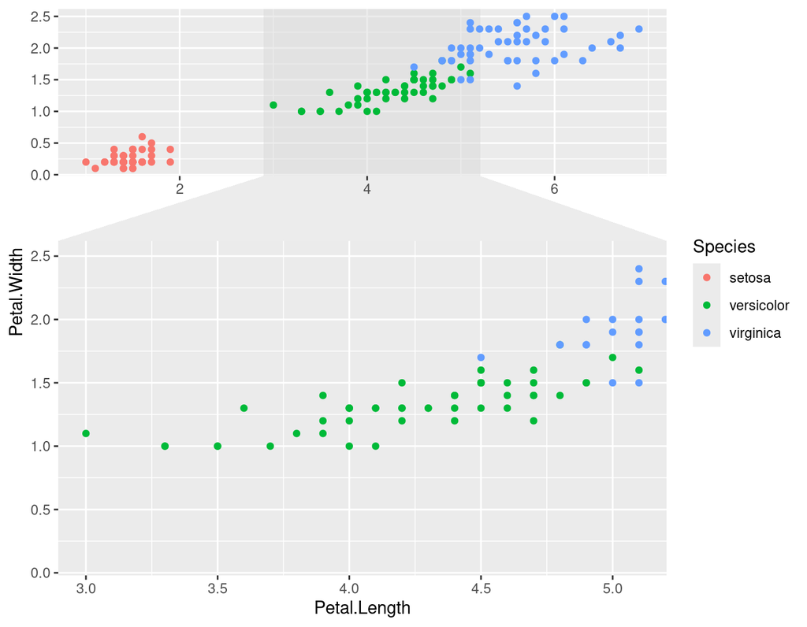

```r
ggplot(iris, aes(Petal.Length, Petal.Width, colour = Species)) +
  geom_point() +
  ggforce::facet_zoom(x = Species == "versicolor")
```

El paquete/extensión `ggforce` es pretty awesome. En [este post](https://rviews.rstudio.com/2019/09/19/intro-to-ggforce) puede verlo en acción haciendo mapas.

Otro enfoque para hacer anotaciones, bueno, en realidad centrase en un grupo de observaciones es utilizar el paquete [`gghighlight`](https://github.com/yutannihilation/gghighlight):

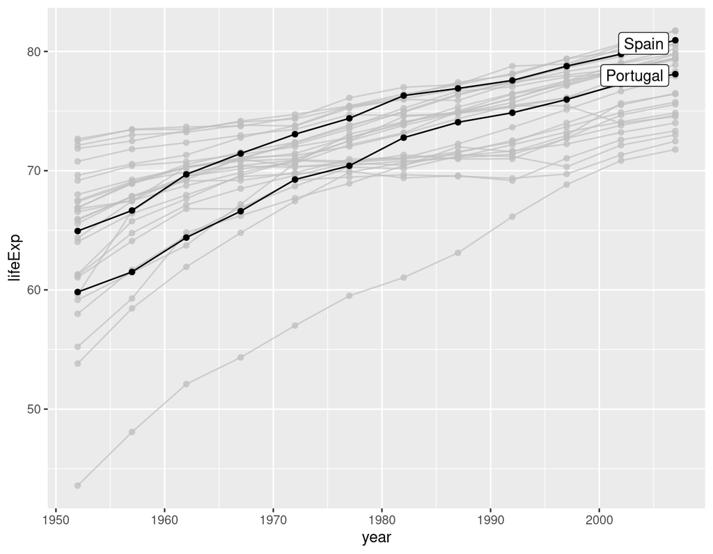

```r
df <- gapminder::gapminder %>% filter(continent == "Europe")
ggplot(df, aes(year, lifeExp, group = country)) +
  geom_line() +
  geom_point() +
  gghighlight::gghighlight(country %in% c("Spain", "Portugal"))
```

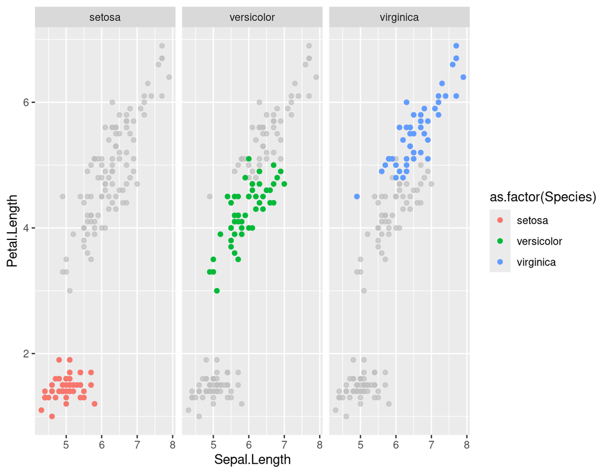

```r
ggplot(iris, aes(Sepal.Length, Petal.Length, color = as.factor(Species))) +
  geom_point() +
  gghighlight::gghighlight() +
  facet_wrap(vars(Species))
```

## 8. Asistentes para ggplot2

Ahora mismo existen 2 asistentes para crear gráficos ggplot a través de interfaces gráficas: [`ggThemeAssist`](https://github.com/calligross/ggthemeassist) y [`esquisse`](https://dreamrs.github.io/esquisse/index.html)

- El paquete [`ggThemeAssist`](https://github.com/calligross/ggthemeassist) facilita mediante un adding de RStudio la edición de los detalles de un gráfico; es decir, puedes comenzar haciendo un gráfico básico en RStudio, para después abrir la interfaz de `ggThemeAssist` para modificar con el asistente visual todos los elementos estéticos de gráfico como títulos, leyendas, colores etc… etc…

  Para ello, primero has de instalar el paquete con `install.packages("ggThemeAssist")`, después cargarlo con `library(ggThemeAssist)`. Una vez has cargado el paquete en memoria has de seleccionar con el cursor el código que genera el ggplot que quieres modificar/tunear. Una vez tienes marcado con el ratón el código del gráfico, has de seguir, en RStudio, esta ruta de menús: `Tools > Addings > Browse Addings ...`, para seleccionar finalmente el adding llamado “ggplot Theme Asistant”.

  Se abrirá un interfaz donde podrás modificar la mayoría de elementos del gráfico. Cuando hayas dejado el gráfico a tu gusto pinchas en `DONE` y te devolverá el código que reproduce el gráfico tal y como lo elegiste en el interfaz.

  Podéis ver un ejemplo en https://github.com/calligross/ggthemeassist
- El paquete [`esquisse`](https://dreamrs.github.io/esquisse/index.html) permite crear gráficos ggplot desde cero con una interfaz gráfica.

  Para usarlo tienes que instalarlo con `install.packages("esquisse")` para luego abrirlo siguiendo esta ruta de menús en RStudio: `Tools > Addings > Browse Addings ...` para elegir el adding con nombre: “esquisse - ggplot builder”.

> You might not be a pro at ggplot but you can still do amazing stuff with the 'esquisse' package that makes ggplot quite easy.  
> After downloading it, you will find it under “Addins” named ggplot2 builder, click on it to get started on the drag and drop plotting🤓 [pic.twitter.com/30fBbgvYjq](https://t.co/30fBbgvYjq)

> — We are R-Ladies (@WeAreRLadies) [June 14, 2019](https://twitter.com/WeAreRLadies/status/1139591763432222723?ref_src=twsrc%5Etfw)

## 9. Gráficos interactivos

Los gráficos interactivos, como su nombre indica, permite al usuario interactuar con el gráfico, abriéndose posibilidades como centrarse en parte del gráfico (zooming), highlighting, o mostrar información adicional al pinchar en algún elemento del gráfico, etc …

En general, JavaScript (JS) es el lenguaje utilizado para hacer gráficos interactivos con librerías como D3, Chart, Plotly, Vis Highcharts, …

Recientemente, el paquete de R [`htmlwidgets`](http://www.htmlwidgets.org/) ha facilitado el uso de las librerías de JS en R. Actualmente, paquetes de R, como leaflet, DT, dygraphs, networkD3 y muchos otros, utilizan el framework propuesto por htmlwidgets para hacer disponibles los gráficos interactivos de JS en R.

Para daros cuenta de lo fácil que es hacer un gráfico interactivo con R usaremos el paquete [`plotly`](https://plot.ly/r/) que hace posible usar la librería plotly.js en R. Con `plotly` se pueden hacer muchos tipos de gráficos, pero por ejemplo, permite con una sola linea convertir un gráfico ggplot en interactivo:

```r
library(plotly)
p <- ggplot(iris, aes(Sepal.Length, Petal.Length, color = Species)) +  geom_point() + geom_smooth()
ggplotly(p)
```

[Aquí](https://plotly-r.com/preface.html) puedes encontraar un bookdown sobre plotly.

```r
p1 <- p + facet_grid(cols = vars(Species))
ggplotly(p1)
```

```r
p <- ggplot(mpg, aes(class)) +  geom_bar(fill = "steelblue") + coord_flip()
ggplotly(p)
```

[Aquí](https://www.r-graph-gallery.com/interactive-charts.html) puedes ver un galería de ejemplos de gráficos interactivos hechos con R. [Aquí](https://moderndata.plot.ly/interactive-r-visualizations-with-d3-ggplot2-rstudio/) un post, ya de 2015, para iniciarse un poco en estos temas.

Hay muchos paquetes que permiten hacer gráficos interactivos en R, por ejemplo [`leaflet`](http://rstudio.github.io/leaflet/), que permite hacer mapas interactivos muy fácilmente.

```r
library(leaflet)
m <- leaflet()
m <- addTiles(m)
m <- addMarkers(m, lng = 174.768, lat =-36.852, popup = "The birthplace of R")
m
```

Todos estos paquetes[^10] que permiten hacer gráficos interactivos a través de `htmlwidgets` se pueden consultar en: http://gallery.htmlwidgets.org/. Dos paquetes que no están en la gallery: [`Apexcharts`](https://cran.r-project.org/web/packages/apexcharter/vignettes/starting-with-apexcharts.html) y [`TSplotly`](https://cran.r-project.org/web/packages/TSplotly/vignettes/TSplotly.html).

En [Interactive web-based data visualization with R, plotly, and shiny](https://plotly-r.com/) explican más detalladamente como hacer gráficos interactivos en R. Tendré que releer su sección [Saving and embedding HTML](https://plotly-r.com/saving.html) para mostrar en el tutorial alguno de los gráficos dinámicos que he hecho, pero ahora tengo prisa, la próxima clase es pronto y empezamos sí o sí ggplot2.

Hadley también está escribiendo un bookdown sobre Shiny: [Mastering Shiny](https://mastering-shiny.org/). En palabras de Hadley: Shiny is a framework for creating web applications using R code. Para ver que significa esto puedes ver la siguiente [galería con ejemplos de aplicaciones shiny](https://shiny.rstudio.com/gallery/).

### gganimate

[`gganimate`](https://gganimate.com/) es un paquete que no hace gráficos dinámicos, pero permite animar gráficos mediante la creación creación de secuencias de gráficos. Mejor que explicarlo visita su sección de ejemplos en su wiki: https://github.com/thomasp85/gganimate/wiki. Por ejemplo [este ejemplo](https://github.com/thomasp85/gganimate/wiki/Tracking-of-hurricanes-and-typhoons) o [este ejemplo](https://github.com/thomasp85/gganimate/wiki/World-Cup-Goal-Animation) de jurgol. En [este post](https://www.datanovia.com/en/blog/gganimate-how-to-create-plots-with-beautiful-animation-in-r/) explican como usarlo.

Un ejemplo con los datos de `gapminder`

```r
library(tidyverse)
library(gapminder)
library(gganimate)
gapmider_europe <- gapminder %>% filter(continent == "Europe")
ggplot(gapmider_europe, aes(gdpPercap, lifeExp, size = pop, colour = country)) +
  geom_point(alpha = 0.7, show.legend = FALSE) +
  scale_colour_manual(values = country_colors) +
  scale_size(range = c(2, 12)) +
  scale_x_log10() +
  facet_wrap(~continent) +
  # Here comes the gganimate specific bits
  labs(title = 'Year: {frame_time}', x = 'GDP per capita', y = 'life expectancy') +
  transition_time(year) +
  ease_aes('linear')
```

[Aquí](https://gist.github.com/thomasp85/05169ad44ddcc8ed56da6ff7bf7fbe36) tienes un ejemplo para hacerlo para los cinco continentes.

## Biblio/ejemplos/recursos

Son recursos que he visto o utilizado mientras escribía esta notas, y no quiero olvidarlos:

- [Bookdown oficial sobre ggplot2](https://ggplot2-book.org/)
- [Webinar de Thomas L. Pedersen sobre ggplot2](https://www.youtube.com/watch?v=h29g21z0a68&feature=youtu.be)
- [Data Visualization with R de R. Cabacoff](https://rkabacoff.github.io/datavis/index.html).
- [Cédric Scherer](https://github.com/Z3tt/TidyTuesday): una serie de visualizaciones increíbles asociadas al proyecto tidy Tuesday.
- [data-to-viz](https://www.data-to-viz.com/): una plantilla que te puede ayudar a decidir qué gráfico usar.
- [r-statistics.co](http://r-statistics.co/ggplot2-Tutorial-With-R.html): tutorial `ggplot2`.
- [A ggplot2 Tutorial for Beautiful Plotting in R](https://cedricscherer.netlify.com/2019/08/05/a-ggplot2-tutorial-for-beautiful-plotting-in-r/): tutorial `ggplot2`.
- [The Evolution of a ggplot (Ep. 1)](https://cedricscherer.netlify.com/2019/05/17/the-evolution-of-a-ggplot-ep.-1/). Un post muy didáctico donde se va transformando un gráfico hasta hacerlo muy chulo.
- [EDAV info](https://edav.info/box.html). Bookdown aún en construcción con buenos ejemplos.
- [Tom’s Cookbook for Better Viz](https://jthomasmock.github.io/nfl_plotting_cookbook/#license). Un buen tutorial con consejos y demás sobre gráficos ggplot. Por ejemplo mira los “Useful code chunks”.
- [ggplot2 Quick Reference: geom](http://sape.inf.usi.ch/quick-reference/ggplot2/geom). Una cheatsheet para ver los geoms_xx() disponibles
- [Emi Tanaka - 1](https://emitanaka.org/workshopUTokyo2018/day1-session02-datavis.html#1). Son unas tranparencias de Emi Tanaka donde hace un repaso fantástico a la ggplot2 grammar. Emi Tanaka es lo mejor para conocer la verdad sobre ggplot2 en poco tiempo; por ejemplo la slide #6.
- [Data Visualization in the Tidyverse](https://alison.netlify.com/uo-tidy-bakeoff/#1). Otras fantásticas transparencias sobre ggplot2, esta vez de Alison Hill.
- [Preguntas sobre ggplot2 en Stackoverflow](https://stackoverflow.com/questions/tagged/ggplot2). Seguros que encuentras tu pregunta y alguien la ha respondido!!
- [Data Visualization with ggplot2](https://cengel.github.io/R-data-viz/data-visualization-with-ggplot2.html). Un bookdown sobre ggplot2. No lo he leído pero tiene buena pinta para iniciarse con ggplot.
- [practicalgg](https://wilkelab.org/practicalgg/). Un paquete con ejemplos de 6 visualizaciones explicadas paso a paso.
- [viz-pub](https://buff.ly/2nzMZPX). Un repo de Github con gráficos y visualizaciones, obviamente con el código.
- [The ggplot flipbook](https://evamaerey.github.io/ggplot_flipbook/ggplot_flipbook_xaringan.html#1). Otras transparencias sobre ggplot2, de Gina Reynolds.
- [Artistic coding for the useR](https://www.williamrchase.com/post/artistic-coding-for-the-user-12-months-of-art-june/). Un post de Will Chase para introducirse en el mundo de hacer aRte con R.
- [You can replicate almost any plot with R](https://simplystatistics.org/2019/08/28/you-can-replicate-almost-any-plot-with-ggplot2/). Impresionante post de Rafael Irizarry donde replica con R 5 visualizaciones.
- [Data, movies and ggplot2](http://smarterpoland.pl/index.php/2018/12/data-movies-and-ggplot2/). Unos posters increíbles hechos con R.
- La revista [**Buzzfedd**](https://www.buzzfeednews.com/) mantiene una serie de [repos en Github](https://github.com/BuzzFeedNews/) con el código y datos para replicar sus análisis. En concreto, en [este repo](https://github.com/BuzzFeedNews/everything) hay un listado de análisis. Como ejemplo, [este gráfico](https://twitter.com/paldhous/status/1190022664808783872/photo/1), aparece en [este artículo](https://www.buzzfeednews.com/article/lamvo/social-sentinel-school-officials-shootings-flag-social-media), y el código para replicarlos está [aquí](https://buzzfeednews.github.io/2019-10-social-sentinel/).

Por último 3 repos de Github asociados al proyecto [Tidytuesday](https://github.com/rfordatascience/tidytuesday). Absolutamente impresionantes!!!

- https://github.com/gkaramanis/tidytuesday/tree/master/week-38
- https://github.com/spren9er/tidytuesday
- https://github.com/othomantegazza/code-tidytuesday

## Mas biblio

- [A Grammar of Graphics for Python](https://plotnine.readthedocs.io/en/stable/index.html). `Plotnine` is an implementation of a grammar of graphics in Python, it is based on `ggplot2`.
- [Python Plotting for Exploratory Data Analysis](https://pythonplot.com/). Un recorrido por los sistemas gráficos de Phyton.
- [ggplot2tor](https://ggplot2tutor.com/). Un sitio web con buenos tutoriales sobre ejemplos de gráficos ggplot. Van mejorando el gráfico poco a poco. Por ejemplo [este tutorial sobre powerlifting](https://ggplot2tutor.com/powerlifting/squats/)
- Un [ejemplo de dotplot](https://ikashnitsky.github.io/2019/dotplot/) Ilya Kashnitsky de Aquí está el [gist](https://gist.github.com/ikashnitsky/2f3e2b2af6f50911bb775bbce6eb0fb8).
- [R Graphics Cookbook](https://r-graphics.org/)
[^1]: El repo donde se aloja el código para recrear el libro está [aquí](https://github.com/clauswilke/dataviz)
[^2]: Tienes que entender porque son equivalentes. Busca la ayuda de la función y verás que el primer argumento de la función es data, así que si, como ocurre en la segunda expresión, no ponemos el nombre del argumento de la función, R tomará iris como el valor del primer argumento. Parece un trabalenguas pero es importante
[^3]: Si alguno de vosotros me pregunta por la verdad adoptaré semblante hierático y sólo diré lo siguiente: geom_point() is a short-hand for layer(geom = “point”, stat = “identity”, position = “identity”) ó apelaré a la canción de Albert Pla, según me de.
[^4]: En `aes()` no sólo puedes poner variables, sino transformaciones de ellas, por ejemplo aes(x = v1 ^ 2, y = v1 / v2). También se pueden mappear variables con constantes aes(x = 1, colour = “loquesea”)
[^5]: En este caso sí quiero que me preguntéis por este detalle. Es algo que ya deberías saber/intuir pero …
[^6]: En realidad la tercera expresión sí correrá, pero sólo mostrará los puntos, no las lineas.
[^7]: Desafortunadamente ya no se puede ver el tweet porque su autor limitó su visualización; el código si se puede ver
[^8]: O marcar/anotar los lirios 2 lirios más grandes o el lirio mediano. ¿Lo hacéis?
[^9]: Por ejemplo, piensa que lo que se visualiza con `geom_smoth()` no son los datos originales sino, por ejemplo, la linea de regresión si usamos `geom_smoth(method = "lm")`
[^10]: En el momento de escribir estas notas eran 107 paquetes